# Congressional Retirements, 1789-2024

Two centuries of members leaving the House, and the one thing the record will not say

Democracy’s Data

Last updated September 13, 2026 at 10:53a EDT

The election is how voters fire a member of Congress. That is the design the Constitution leans on: two-year terms, the whole House on the ballot every time, and a member who serves badly sent home.[^1] The sentence assumes that when a member leaves, the voters did the removing. Did they? That is a question a citizen has a stake in, because if the answer is no, then the check on the House is not the one the civics class describes.

The record can answer it, member by member. Between 2004 and 2022, 790 members left the House, and for each one the files say whether any voter was involved. **507 of them, 64 percent, never stood on a ballot they could have lost.** Most departures from the modern House are chosen, not imposed, and the rest of this brief is about counting that honestly and asking what the choices signal.

## The test

Using the membership rosters of the House, 1789 to 2025, joined to the federal record of who ran and how they did. Three files are stacked, and they are not equally good. Voteview’s member file is the machine-readable form of the official membership record: one row per member per **Congress** — the numbered two-year session that convenes after each House election, so the 118th Congress is the one that met in 2023 and 2024 — back to the First, maintained by political scientists at UCLA and downloadable at https://voteview.com/data. The Federal Election Commission’s (the FEC’s) *Federal Elections* compilations, 2004–2022, report every House candidate’s vote in the **primary**, the election each party holds to choose its nominee, and in the general election in November, compiled from the states’ official canvasses and downloadable at https://www.fec.gov/introduction-campaign-finance/election-results-and-voting-information/. Brookings’ *Vital Statistics on Congress* counts retirements and defeats back to 1946, and gives the derivation something independent to be checked against.

A roster is the only instrument that can hold this question. Leaving is a membership fact: a person served in Congress *N* and did not serve in Congress *N+1*, which the roster states for 118 consecutive Congresses with no inference at all. A returns file cannot see the member who never appears on a ballot, and that member is precisely the subject. The roster chapter introduces this record, what it was made for, and why most House turnover is invisible to election returns.

| Source | What | Covering | Kind |
| --- | --- | --- | --- |
| Voteview member file | Every member of every Congress | 1789 to 2025 | Compiled by researchers, out of roll calls |
| FEC, *Federal Elections* | Every House candidate, with primary and general votes | 2004 to 2022 | A federal agency’s own publication |
| Brookings, *Vital Statistics on Congress* | Retirements, primary defeats, general defeats, counted | 1946 to 2024 | Compiled from other people’s counts |

## The data

Put the roster beside the candidate file and each departing member falls into one of four places:

| What the files show | What it is called |
| --- | --- |
| Not on any House ballot | Did not seek re-election |
| On the primary ballot, not nominated | Denied renomination |
| Nominated, lost in November | Defeated in the general election |
| Nominated, won | Re-elected |

The first of those four is a residual, the category for what is left over, and residuals are where the trouble is. A graceful retiree, a member resigning under indictment, and a member quitting ahead of an expected defeat all land in it together. Deaths can be pulled out, because the roster records a death year; Senate runs can be pulled out, because those members appear on the FEC’s Senate side. What remains is not “retirement” in any sense that means *chose to stop*. It is *did not appear on a ballot*, and no file records the difference.

The joined table, `exits.csv`, carries one row per sitting member per election cycle. Each row names `congress`, `state_abbrev`, `district_code` and `election_year`. `on_house_ballot` says whether the member appears anywhere in that cycle’s candidate file. `denied` and `ge_win` hold the primary and November verdicts where a verdict exists, and `outcome` is the classification assembled from the other three. Here is one member, re-elected in one cycle and absent from the next:

| Congress | State abbrev | District code | Election year | On house ballot | Denied | Ge win | Outcome |
| --- | --- | --- | --- | --- | --- | --- | --- |
| 112 | MI | 8 | 2012 | TRUE | FALSE | TRUE | re-elected |
| 113 | MI | 8 | 2014 | FALSE | FALSE | FALSE | did not seek re-election |

Read the two rows. In the first, Mike Rogers of Michigan holds his seat in the 112th Congress; the 2012 candidate file contains him (`on_house_ballot` is TRUE), his party did not refuse him renomination (`denied` is FALSE), and he won in November (`ge_win` is TRUE), so the outcome is *re-elected*. In the second he holds the same seat in the 113th Congress, and the 2014 candidate file does not contain him at all: `on_house_ballot` is FALSE, so `denied` and `ge_win` have nothing to record. The roster gives him no death year, and the FEC’s Senate file does not list him either, so he falls into the residual: *did not seek re-election*. That is everything the two files can say. Whether he chose to go, or read the district and decided not to try, is in neither.

One column in the roster quietly stops. `occupancy`, the only field recording mid-term replacements, is filled through the 114th Congress and empty after it, with no footnote and no warning:

| Congress | Share of House rows with occupancy filled |
| --- | --- |
| 110 | 0.989 |
| 112 | 1.000 |
| 113 | 1.000 |
| 114 | 1.000 |
| 115 | 0.000 |
| 116 | 0.000 |
| 117 | 0.000 |
| 118 | 0.000 |
| 119 | 0.000 |

That cliff decides the denominator, the bottom number every rate here is divided by. The natural unit would be the 435-member class a general election seats, which is exactly what `occupancy` would isolate and cannot after 2015. So the denominator throughout is everyone who held a House seat during a Congress: 445 people in the Congress that met in 2023, not 435 seats. Brookings counts the other way, which is one reason the two series run close without ever quite meeting.

> **Before you read on, commit to a number.** Between 2004 and 2022, 790 members left the House. How many of them do you expect were removed by voters — beaten in November by the other party, or refused renomination by their own? Write down a count, or a share of 790, before you look at the figures.

## What it says about democracy

The long view first, because the modern House is the strange one.

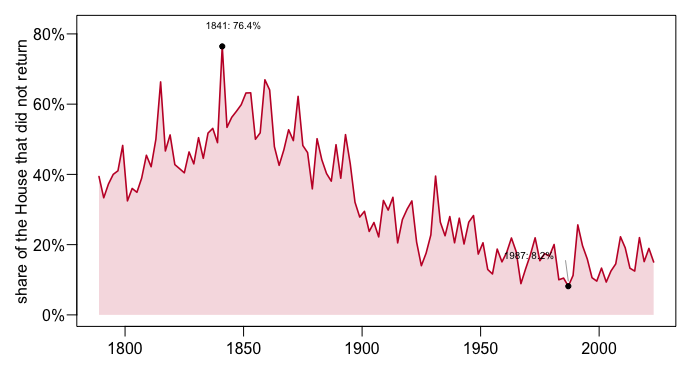

**Figure 1. The share of the House that did not come back, every Congress from 1789 to 2023.** An area on a time axis, because the quantity is a share of one chamber measured 118 times at even intervals. The finding is the shape of the whole series: a chamber that once emptied itself, and stopped. The peak is 1841, when 76 percent of the House did not return; the floor since 1900 is 1987, at 8.2 percent.

| Period | Share who did not return |
| --- | --- |
| 1789–1830 | 42.7% |
| 1831–1870 | 55.1% |
| 1871–1900 | 43.8% |
| 1901–1940 | 26.0% |
| 1941–1980 | 18.4% |
| 1981–2024 | 15.0% |

The fall is the professionalization of Congress. Polsby (1968) described the House acquiring boundaries, an internal career structure and seniority rules — an institution rather than a way station.[^2] Members stopped going home because there came to be something worth staying for. The question this brief asks starts where that story finishes: once turnover has fallen this far, who does the removing?

| Outcome | Members | Share |
| --- | --- | --- |
| Re-elected | 3,653 | 82.2% |
| Did not seek re-election | 387 | 8.7% |
| Defeated in the general election | 225 | 5.1% |
| Ran for the Senate | 102 | 2.3% |
| Denied renomination | 58 | 1.3% |
| Died in office | 18 | 0.4% |

Those are the 4,443 member-cycles — one sitting member facing one election — from 2004 to 2022. Four out of five members came back. Of the 790 who left, voters removed 283: 225 beaten in November, 58 denied renomination by their own party. The other 507, 64 percent of all departures, faced no voter at all. **The modal way to leave the House of Representatives is to stop being a candidate for it.**

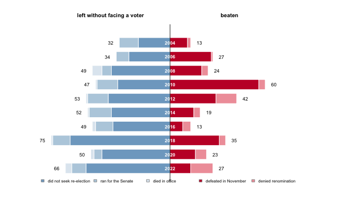

**Figure 2. Every House departure from 2004 to 2022, split at the line.** To the left of each year, members who left without standing on a ballot they could lose; to the right, members somebody defeated. The left side totals 507 and the right side 283. Most readers place the primary share far too high: a sitting member is roughly 3.9 times more likely to be beaten in November than to be refused renomination.

The wrong lesson would be that the House is safe and nothing changed. What changed is who does the removing. Compare the earliest and latest quarter centuries of the Brookings series:

|  | 1946–1970, per election | 2000–2024, per election |
| --- | --- | --- |
| Retired | 28.2 | 38.0 |
| Defeated in a primary | 8.5 | 5.8 |
| Defeated in November | 31.3 | 17.5 |

The two lines swapped. In the first postwar quarter century, November removed about 31 members a cycle and 28 left on their own; in the most recent, November removes 17 and 38 leave. That is the same fact the `house-competition` brief reaches from the other side: where the November result is a foregone conclusion, the seat empties only when its occupant decides to go.

If departures are decisions, they should respond to circumstances, and they do — in patterns worth telling. The first is the redistricting cycle: after each ten-year census every state redraws its House district lines, and the first election on the new map is the one held in a year ending in 2. Those elections against all the others:

| Election | Retirements | Primary defeats | General defeats |
| --- | --- | --- | --- |
| First on a new map (years ending in 2) | 41.8 | 12.0 | 19.8 |
| All other years | 34.0 | 5.2 | 23.4 |

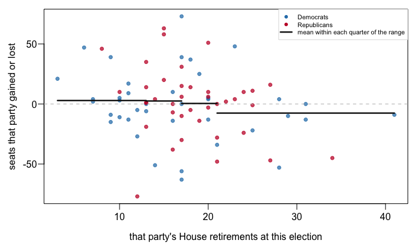

**Figure 3. Retirements against seats won or lost, one point per party per election, 1946 to 2022.** Retirement counts from Brookings; each party’s seat change computed from the roster. The horizontal bars are the mean seat change within each quarter of the retirement range: 2.9, 2.5, 0.4 and -7.6 seats.

**A wave of retirements is a political signal, but only when it is a wave.** Below about 21 retirements, a party’s count says nothing about how the election will go; above it, the average party loses 7.6 seats. Across all 78 points the correlation is -0.22, far too loose for the forecasting tool it is treated as on television. And the figure cannot say which way the arrow runs: members reading the polls, or parties recruiting badly in the same bad years, fit it equally well.[^3]

## What this brief cannot tell you

**It never observes a decision.** “Did not seek re-election” is a category of ignorance. It holds the member who wanted to leave and the member who ran out of options, and telling them apart would need a record of intent no agency keeps. Every sentence above about departure being chosen is a sentence about a category that also holds the pushed.

**It cannot reach 2024 from the returns.** The FEC had published no 2024 compilation when this was written, so the four-way sorting stops at 2022 while the membership series runs to 2023. The Brookings column covers 2024 and is not built from returns.

**Its death rule is an approximation.** The roster records a death year, not a date, so a member who left in January and died in November cannot be told from one who died in office. The rule used is conservative, and it undercounts.

**And two centuries are not one series.** A departure in 1841 and one in 2021 are counted identically, and they are not the same event. Multi-member districts, dissolving parties, and House careers that ran through state legislatures all sit inside the steep part of Figure 1.

## Extensions

None of these is answered above, and every one can be answered from the tables the Sources section hands over.

- `exits_by_year.csv` splits every departure into `reelected`, `lost_general`, `denied`, `senate_run`, `died` and `not_running`. Compute each one’s share of `members` by year. Does the chosen-versus-imposed balance hold in every cycle, or do wave years break it?
- `departures.csv` runs back to the first Congress with `pct_left`. Follow it and decide when serving in the House stopped being something people did briefly. Is the fall steady, or in steps?
- `vsoc.csv` carries `retired`, `lost_primary` and `lost_general` for every election since 1946. Group by whether `year` ends in 2 and check the redistricting pattern for yourself.
- `compare.csv` shows three sources counting the same primary defeats, with `gap_brookings` and `gap_giroux`. Find a year where they disagree and decide which source you would trust, and why.
- **Stretch.** When the FEC publishes its 2024 *Federal Elections* workbook, extend the sorting two more years and see whether the 2022 pattern held.
- **Stretch.** Pick one high-retirement cycle and find each retiring member’s announcement date in a news archive. Do the announcements cluster before or after the polls turned against the party?

## Sources

**Data**

- Lewis, J. B., Poole, K., Rosenthal, H., Boche, A., Rudkin, A. and Sonnet, L. *Voteview: Congressional Roll-Call Votes Database*, member file `HSall_members.csv`. https://voteview.com/data — retrieved 2026-08-11, 51,062 rows, Congresses 1 to 119.
- Federal Election Commission, *Federal Elections*, biennial compilations for 2004 through 2022. https://www.fec.gov/introduction-campaign-finance/election-results-and-voting-information/ — retrieved 2026-08-11, 10 workbooks, 22,156 House candidate rows. Compiled by the Commission from the official canvasses of the state election officials.
- Brookings Institution, *Vital Statistics on Congress*, Chapter 2, edition of April 2026, Table 2-7 (House incumbents retired, defeated or re-elected, 1946–2024) and Table 2-9 (House and Senate retirements by party). https://www.brookings.edu/articles/vital-statistics-on-congress/
- Giroux, G. *Members of Congress Defeated For Renomination, 1966–2026.* Publicly shared spreadsheet; used here only as an independent check on the primary-defeat counts, on which this build, Brookings and Giroux agree exactly in 7 of 10 elections and are never more than one apart. https://docs.google.com/spreadsheets/d/1X97S6hUby6PPHAMoEwvAxkAUo8EUwLk8xMosx4hVd8c/

**The data itself**

Every figure above is drawn from these tables. They are plain CSV, they open in a spreadsheet, and they are yours to take further.

`compare.csv`, `departures.csv`, `dropped.csv`, `exits.csv`, `exits_by_year.csv`, `recovered.csv`, `unmatched.csv`, `vsoc.csv`, `vsoc_party.csv`

One more file is not data about the subject – it is how this chapter checked its own work: `checks.csv`, the arithmetic verified before anything was drawn.

**Academic literature**

- Polsby, N. W. (1968). “The Institutionalization of the U.S. House of Representatives.” *American Political Science Review* 62(1): 144–168. https://www.jstor.org/stable/1953331
- Jacobson, G. C. (1989). “Strategic Politicians and the Dynamics of U.S. House Elections, 1946–86.” *American Political Science Review* 83(3): 773–793. https://www.jstor.org/stable/1962397
- Mayhew, D. R. (1974). *Congress: The Electoral Connection.* Yale University Press.
- Jacobson, G. C. and Carson, J. L. (2019). *The Politics of Congressional Elections.* 10th ed. Rowman & Littlefield.

Rebuild this data yourself, with an AI assistant

[output not shown]

[^1]: U.S. Const. art. I, § 2, text at https://www.law.cornell.edu/constitution/articlei#section2.
[^2]: Nelson W. Polsby, “The Institutionalization of the U.S. House of Representatives,” *American Political Science Review* 62, no. 1 (1968): 144–168, https://www.jstor.org/stable/1953331.
[^3]: The first reading is Jacobson’s *strategic politicians* account, in which experienced candidates and sitting members alike time their decisions to the national climate: Gary C. Jacobson, “Strategic Politicians and the Dynamics of U.S. House Elections, 1946–86,” *American Political Science Review* 83, no. 3 (1989): 773–793, https://www.jstor.org/stable/1962397; the textbook version is Jacobson and Carson, cited below.